# Reproducible Research: Peer Assessment 1

Madina Baizhanova

7/29/2020

The purpose of this assignment is to answer the questions given below.

The data for this assignment comes from a personal activity monitoring device, which collected data on the number of steps taken at 5 minute intervals throughout the day from October 01 to November 30 of 2012.

In order to access the data set I forked the repository in GitHub (to access the repository follow the [URL](https://github.com/rdpeng/RepData_PeerAssessment1)) and made a clone of it by creating a new project in R Studio.

## Loading and preprocessing the data

First, I have loaded the packages that will be needed for data manipulation and making plots. Then, I unzipped the **activity.zip** file using unzip() function and read the **activity.csv** file into R by read.csv() function and assigned it to the *activity* variable.

```r
library(dplyr)
```

```r
library(lattice)
library(ggplot2)
unzip("activity.zip")
activity <- read.csv("activity.csv")
dim(activity)
```

```
## [1] 17568     3
```

```r
head(activity)
```

```
##   steps       date interval
## 1    NA 2012-10-01        0
## 2    NA 2012-10-01        5
## 3    NA 2012-10-01       10
## 4    NA 2012-10-01       15
## 5    NA 2012-10-01       20
## 6    NA 2012-10-01       25
```

From the output of dim() function it can be seen that the loaded data set has 17 568 observations and 3 variables. The result of the head() function gives the names of the variables which are *steps*, *date*, and *interval*.

## What is mean total number of steps taken per day?

First, let’s calculate the total number of steps taken each day. At this step the missing values (NA) are ignored.

```r
totalnumber <- activity %>% group_by(date) %>% summarise(sum(steps))
# Here, I could also use the expression aggregate(steps~date,activity,sum)
colnames(totalnumber) <- c("day", "numberofsteps")
head(totalnumber)
```

```
## # A tibble: 6 x 2
##   day        numberofsteps
##   <chr>              <int>
## 1 2012-10-01            NA
## 2 2012-10-02           126
## 3 2012-10-03         11352
## 4 2012-10-04         12116
## 5 2012-10-05         13294
## 6 2012-10-06         15420
```

Let’s now make the histogram of the total number of steps taken each day.

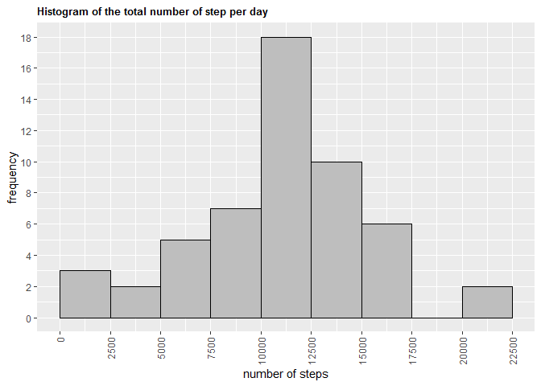

```r
ggplot(totalnumber, aes(numberofsteps))+
        geom_histogram(boundary=0, binwidth=2500, col = "black", fill="grey")+
        ggtitle("Histogram of the total number of step per day")+
        xlab("number of steps")+ylab("frequency")+
        theme(plot.title=element_text(face="bold",size=10),
              axis.text.x=element_text(angle=90,vjust=0.5,hjust=1))+
        scale_x_continuous(breaks=seq(0,25000,2500))+
        scale_y_continuous(breaks=seq(0,20,2))
```

Let’s now find the mean and the median total number of steps per day.

```r
mean(totalnumber$numberofsteps, na.rm = TRUE)
```

```
## [1] 10766.19
```

```r
median(totalnumber$numberofsteps, na.rm = TRUE)
```

```
## [1] 10765
```

Therefore, as can be seen from above the mean and the median of the total number of steps per day are **10766.19** and **10765** respectively.

## What is the average daily activity pattern?

Here, a time series plot of the average number of steps per intervals will be plotted. (5-minute intervals on x-axis and the average number of steps averaged across all days on y-axis)

```r
ANS <- activity %>% group_by(interval) %>% summarise(mean(steps, na.rm=TRUE))
```

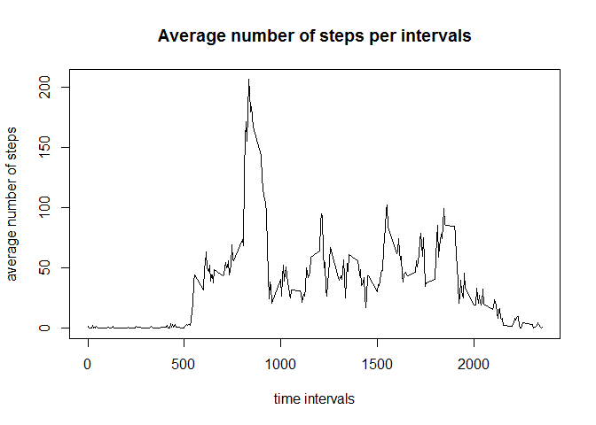

```r
colnames(ANS) <- c("interval", "meanstep")
with(ANS,plot(x = interval,y = meanstep,type = "l", xlab = "time intervals",
              ylab = "average number of steps",
              main = "Average number of steps per intervals"))
```

```r
ANS %>% filter(meanstep==max(meanstep))
```

```
## # A tibble: 1 x 2
##   interval meanstep
##      <int>    <dbl>
## 1      835     206.
```

The last expression in the code chunk with filter() function gives us the 5-min interval which contains the maximum number of steps.

## Imputing missing values

First let’s calculate the number of missing values in the data set.

```r
sum(is.na(activity$steps))
```

```
## [1] 2304
```

```r
filler <- mean(activity$steps, na.rm = TRUE)
na <- is.na(activity$steps)
activity_imputed <- activity # creating a new data set
activity_imputed[na, 1] <- filler # filling in the missing values
totalnumber_imputed <- aggregate(steps ~ date, activity_imputed, sum)
colnames(totalnumber_imputed) <- c("day", "numberofsteps")
head(totalnumber_imputed)
```

```
##          day numberofsteps
## 1 2012-10-01      10766.19
## 2 2012-10-02        126.00
## 3 2012-10-03      11352.00
## 4 2012-10-04      12116.00
## 5 2012-10-05      13294.00
## 6 2012-10-06      15420.00
```

From the output of the head() function it can be seen now that the data set is full and there are no NA values. Let’s now remake the histogram of the total number of steps per day given the new full data set.

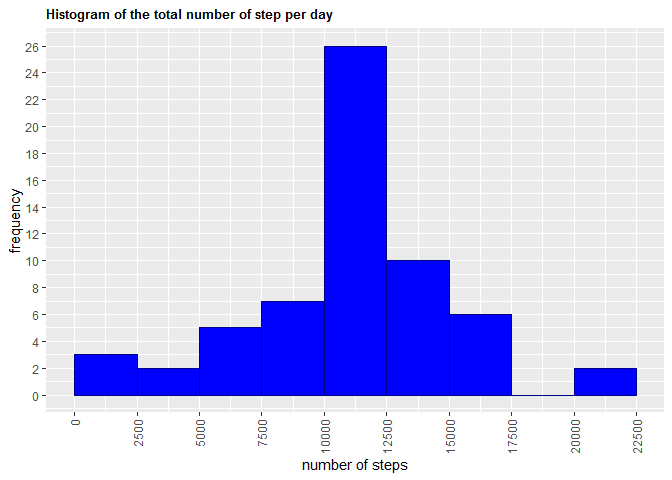

```r
ggplot(totalnumber_imputed, aes(numberofsteps))+
        geom_histogram(boundary=0, binwidth=2500,col="darkblue",fill="blue")+
        ggtitle("Histogram of the total number of step per day")+
        xlab("number of steps")+ylab("frequency")+
        theme(plot.title=element_text(face="bold",size=10),
              axis.text.x=element_text(angle=90,vjust=0.5,hjust=1))+
        scale_x_continuous(breaks=seq(0,25000,2500))+
        scale_y_continuous(breaks=seq(0,26,2))
```

Let’s now recalculate the mean and the median total number of steps per day.

```r
mean(totalnumber_imputed$numberofsteps, na.rm = TRUE)
```

```
## [1] 10766.19
```

```r
median(totalnumber_imputed$numberofsteps, na.rm = TRUE)
```

```
## [1] 10766.19
```

## Are there differences in activity patterns between weekdays and weekends?

For this part of the assignment the new full data set has been used. First, the class of the *date* variable has been transformed to the Date class using the as.Date() function. Then, a new variable *weekday* has been added, which signifies corresponding day of the week. After this, a new factor variable *daytype* has been created using the ifelse() function. This factor variable indicates whether the given date is weekday or week-end.

```r
activity_imputed$date <- as.Date(activity_imputed$date, format = "%Y-%m-%d")
activity_imputed$weekday <- weekdays(activity_imputed$date)
activity_imputed$daytype<-ifelse(activity_imputed$weekday=="Saturday" |
                        activity_imputed$weekday=="Sunday","Week-end","Weekday")
head(activity_imputed)
```

```
##     steps       date interval weekday daytype
## 1 37.3826 2012-10-01        0  Monday Weekday
## 2 37.3826 2012-10-01        5  Monday Weekday
## 3 37.3826 2012-10-01       10  Monday Weekday
## 4 37.3826 2012-10-01       15  Monday Weekday
## 5 37.3826 2012-10-01       20  Monday Weekday
## 6 37.3826 2012-10-01       25  Monday Weekday
```

```r
ANSbydaytype <- aggregate(formula=steps~interval+daytype,data=activity_imputed,
                        FUN = mean,na.action=na.omit)
```

After finding the average number of steps taken per interval, averaged across all weekday days or weekend days, let’s make a time series plot.

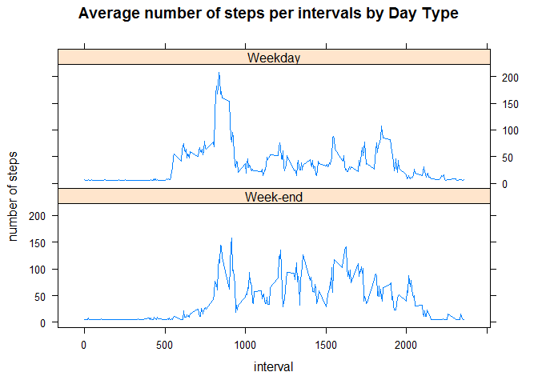

```r
xyplot(steps~interval|daytype,ANSbydaytype,type="l",layout=c(1, 2),
       xlab="interval", ylab = "number of steps",
       main="Average number of steps per intervals by Day Type")
```

On x-axis there are 5-minute intervals, and on the y-axis - the average number of steps averaged across all weekdays and week-ends.